# CAPSTONE PROJECT 1

# Introduction:

## Project Description

This project is about a new Taxi Driver in Takoradi who is determined to use the shortest route on every trip. Trips to and around Dadzie street, a town in Takoradi has the most financial returns. Unfortunatel, the shortest route as mentioned above is heavily patrolled by the police, and with the fines and bribes charged for simply driving through, the shortest route may not be the best choice. Hence, the aim here is to find the route that maximizes the probability of not being stopped by the police. The figure below shows the possible routes from the market circle (1) to Dadzie street (7) and the associated probabilities of not being stopped on each segment.

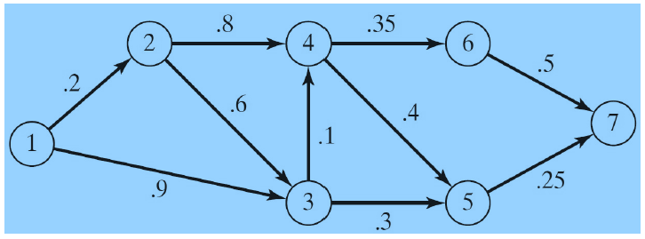

## Problem:

Finding the Optimal solution that helps the Driver decide or choose a route that maximizes the probability of not being stopped by the police, thereby avoiding any fines and bribes that comes with that.

## Goal:

### Selecting the route that **Maximizes** the Probability of not being fined by the Police.

## Problem Solution Steps:

The steps below were used to find the optimal routes with the highest probability.

### Step 1. Import all necessary Libraries.

The first step is to import relevant components of the Dijkstra Algorithm.

```python
#importing all libraries to be used

import dijkstra as ds
import numpy as np
from dijkstra import Graph
from dijkstra import DijkstraSPF
```

### Step 2. Converting all Street (nodes) numbers from 1-7 to A-G

```python
A, B, C, D, E, F, G = nodes = list("ABCDEFG")

graph = Graph()
graph.add_edge(A, B, -np.log10(0.2))
graph.add_edge(A, C, -np.log10(0.9))
graph.add_edge(B, C, -np.log10(0.6))
graph.add_edge(B, D, -np.log10(0.8))
graph.add_edge(C, D, -np.log10(0.1))
graph.add_edge(C, E, -np.log10(0.3))
graph.add_edge(D, E, -np.log10(0.4))
graph.add_edge(D, F, -np.log10(0.35))
graph.add_edge(E, G, -np.log10(0.25))
graph.add_edge(F, G, -np.log10(0.5))

dijkstra = DijkstraSPF(graph, A)
```

### Step 3. Printing out each Label and Distance

```python
#Printing the labels anad their corresponding distance

print("%-5s %-5s" % ("label", "distance"))
for u in nodes:
    print("%-5s %8d" % (u, dijkstra.get_distance(u)))
```

```
label distance
A            0
B            0
C            0
D            0
E            0
F            1
G            1
```

### Step 4. Extracting the path From A to G, the path is:

```python
print(" -> ".join(dijkstra.get_path(G)))
```

```
A -> C -> E -> G
```